# Lesson 24: Exploratory Data Analysis

MAJ Williams

3/24/2021

## Exploratory Data Analysis

What is EDA?

- *The process of transforming and visualizing data in order to better understand the data set, understand the relationships between variables, and to help generate hypotheses to investigate further*

## Let’s do some EDA…

```r
df <- read.csv("merged_data_16-17.csv")

head(df)
```

```
##   X                              INSTNM STABBR
## 1 1            Alabama A & M University     AL
## 2 2 University of Alabama at Birmingham     AL
## 3 3                  Amridge University     AL
## 4 4 University of Alabama in Huntsville     AL
## 5 5            Alabama State University     AL
## 6 6           The University of Alabama     AL
##                                                          ACCREDAGENCY HIGHDEG
## 1 Southern Association of Colleges and Schools Commission on Colleges       4
## 2 Southern Association of Colleges and Schools Commission on Colleges       4
## 3 Southern Association of Colleges and Schools Commission on Colleges       4
## 4 Southern Association of Colleges and Schools Commission on Colleges       4
## 5 Southern Association of Colleges and Schools Commission on Colleges       4
## 6 Southern Association of Colleges and Schools Commission on Colleges       4
##       ADM_RATE_ALL SAT_AVG_ALL PCIP14  UGDS COSTT4_A COSTT4_P TUITIONFEE_IN
```

[output cut: 20 more lines]

#### Answer these questions about your data:

1. What does each row represent?

   ANS: A different college or university
2. How many rows do you have?

   ANS: 7,175 rows – which means 7,175 colleges/universities are listed
3. Are there missing values in your data? How are they coded?

   ANS: Yes. Coded as `NULL` , `PrivacySuppressed`

#### Clean your data:

1. Replace all missing values with `NA`. *Hint*: Take all things called “blank” and replace them with `NA`

   ```r
   df[df == "NULL"] <- NA
   df[df == "PrivacySuppressed"] <- NA
   ```

2. Convert columns that should be numeric…to numeric. *Hint: use the mutate_at() function to mutate a bunch of columns at one time.*

   ```r
   #str(df)

   cols <- c(6:25)

   df[cols] <- sapply(df[cols], as.numeric)
   ```

3. Recode the `HIGHDEG` column so that ‘4’ = ‘bachelors’, ‘3’ = ‘associates’, ‘2’ and ‘1’ = ‘vocational’, ‘0’ = ‘non-degree’. *Hints: use mutate and recode together; `HIGHDEG` must start as a character for recode to work.*

   ```r
   df <- df %>%
     mutate(HIGHDEG = as.character(HIGHDEG)) %>%
     mutate(HIGHDEG = recode(HIGHDEG, "4" = "bachelors", "3" = "associates", "2" = "vocational", "1" = "vocational", "0" = "non-degree"))
   ```

#### Answer the following questions:

1. What are the top 5 schools with the highest in-state tuition?

   ```r
   top <- df %>%
     arrange(-TUITIONFEE_IN) %>%
     top_n(5, TUITIONFEE_IN)

   top %>% select(INSTNM, TUITIONFEE_IN)
   ```

   ```
   ##                                                   INSTNM TUITIONFEE_IN
   ## 1 Aviator College of Aeronautical Science and Technology         71882
   ## 2            Columbia University in the City of New York         55056
   ## 3                                  University of Chicago         53649
   ## 4                                         Vassar College         53090
   ## 5                           Bard College at Simon's Rock         52870
   ```

2. What are the top 5 schools with the lowest in-state tuition?

   ```r
   bottom <- df %>%
     arrange(TUITIONFEE_IN) %>%
     top_n(-5, TUITIONFEE_IN)

   bottom %>% select(INSTNM, TUITIONFEE_IN)
   ```

   ```
   ##                                  INSTNM TUITIONFEE_IN
   ## 1     Haskell Indian Nations University           480
   ## 2                          Dine College           725
   ## 3      Tohono O'Odham Community College           842
   ## 4                Luna Community College           962
   ## 5 Escuela De Troqueleria Y Herramentaje          1040
   ```

3. Count and plot the types of accreditation?

[figure not shown]

   ```r
   acc <- df %>%
     group_by(ACCREDAGENCY) %>%
     summarise(count = n()) %>%
     arrange(count)

   ggplot(data = acc, aes(x = ACCREDAGENCY, y = count)) + geom_bar(stat = "identity")
   ```

4. Is there a relationship between `SAT_AVG` and Admissions Rate? Answer with a plot.

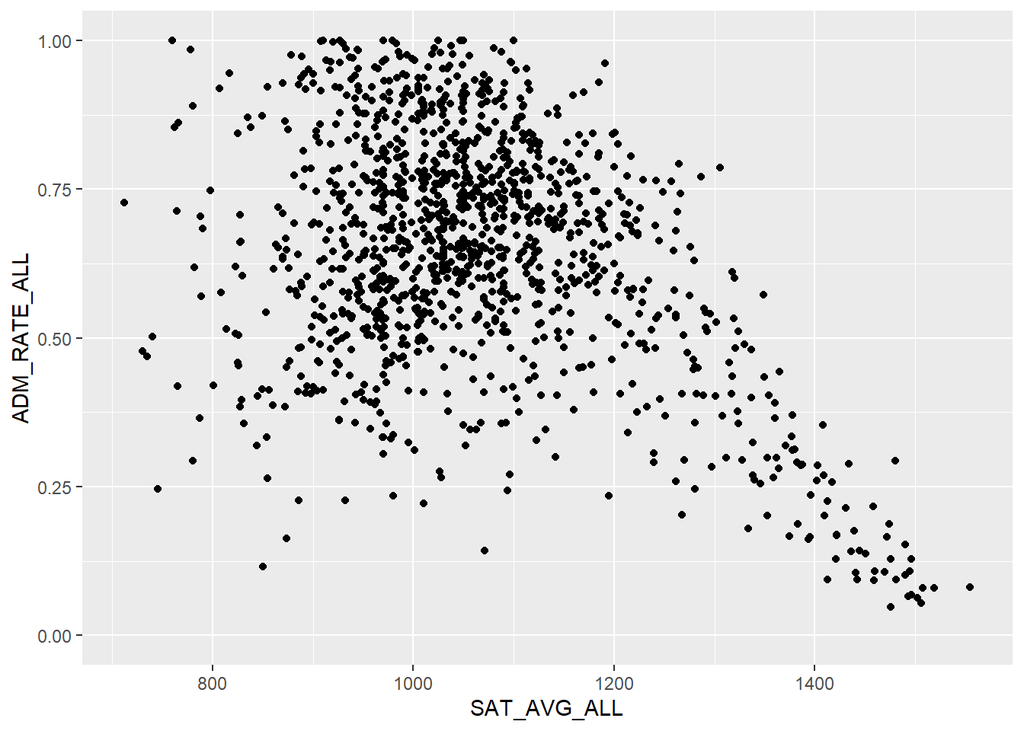

   ```r
   ggplot(data = df, aes(x = SAT_AVG_ALL, y = ADM_RATE_ALL)) + geom_point()
   ```

#### Extra questions (you don’t need to answer these…only for fun!)

1. Is there a relationship between faculty salary and tuition?

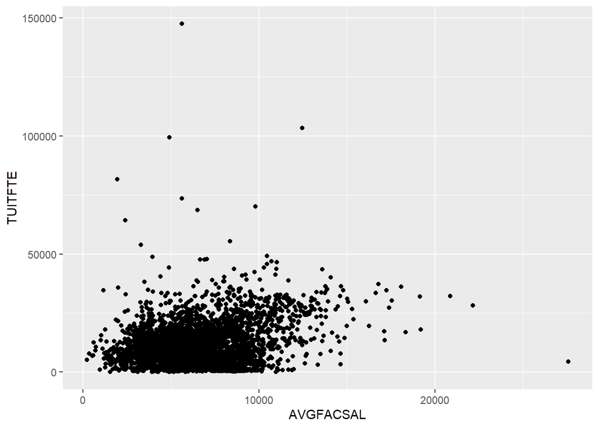

   ```r
   # remove extreme values...
   df_tuit <- df %>%
     filter(TUITFTE <= 200000)

   ggplot(data = df_tuit, aes(x = AVGFACSAL, y = TUITFTE)) + geom_point()
   ```

   *It’s hard to say, but doesn’t appear that there is a relationship – it might be beneficial to try a different visualization for this.*
2. Create facet plots showing the distributions (densities) of SAT scores by degree type?

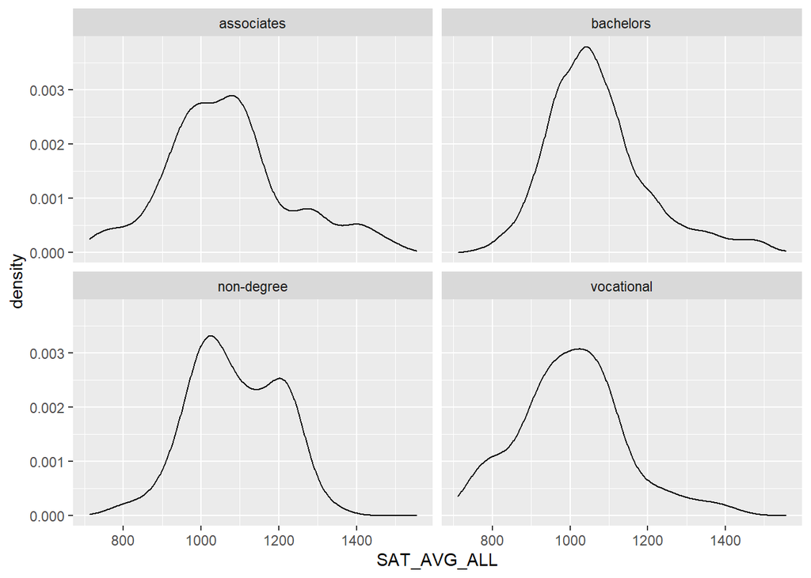

   ```r
   ggplot(data = df, aes(x = SAT_AVG_ALL)) + geom_density() + facet_wrap(~HIGHDEG)
   ```

3. Are entry ages the same for all degree types? Show with a boxplot.

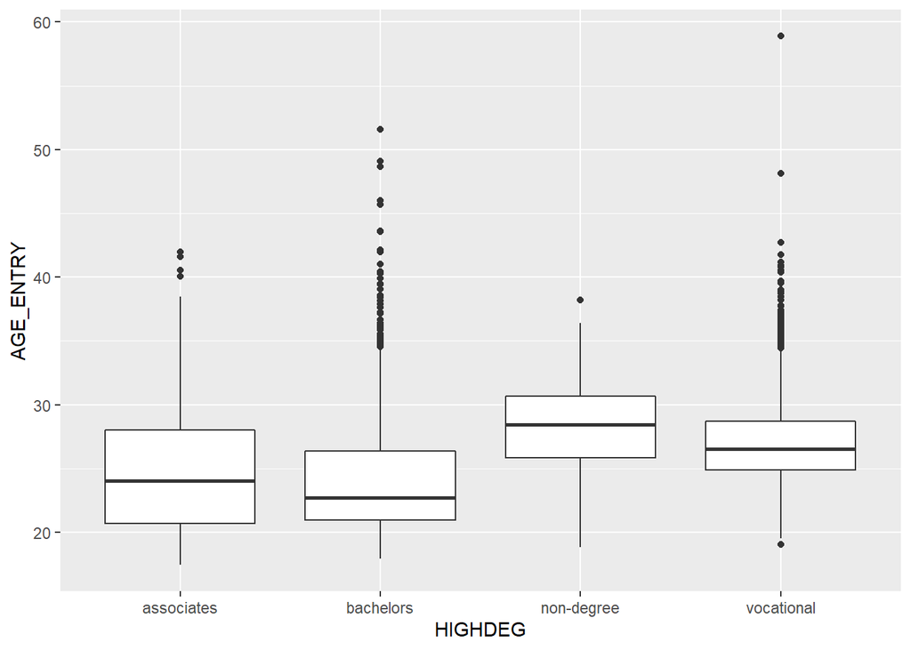

   ```r
   ggplot(data = df, aes(x = HIGHDEG, y = AGE_ENTRY)) + geom_boxplot()
   ```

4. Create a stacked barplot showing the share of men and women for the 10 most expensive out of state tuition.

   ```r
   m_f <- df %>%
     mutate(MALE = 1 - FEMALE) %>%
     select(INSTNM,TUITIONFEE_OUT, FEMALE, MALE) %>%
     drop_na(FEMALE) %>% #remove entries that don't show this split
     top_n(10, TUITIONFEE_OUT) %>%
     pivot_longer(cols = c("FEMALE", "MALE"), names_to = "GENDER", values_to = "PROPORTION")
   ```

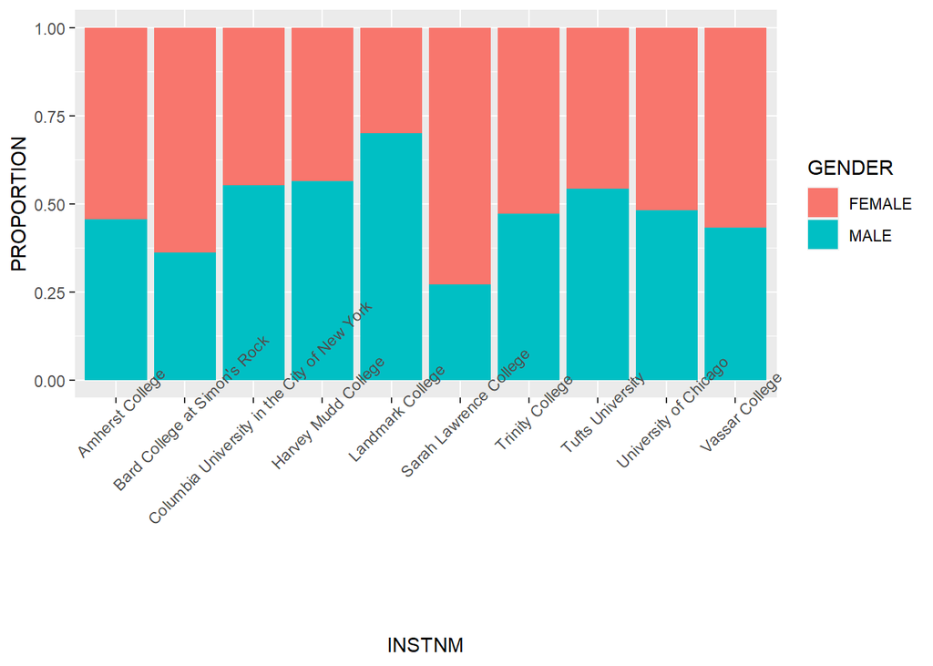

```r
ggplot(data = m_f, aes(x = INSTNM, y = PROPORTION, fill = GENDER)) + geom_bar(stat = "identity") + theme(axis.text.x = element_text(angle = 45))
```